# The qualified self

Michele Silva

## Introduction

The quantified self movement is a group of enthusiasts who take measurements about themselves regularly to improve their health, to find patterns in their behavior, or because they are tech geeks. They regularly quantify how much of a particular activity they do, but they rarely quantify how well they do it. In this project we explore the “qualified self”.

Source: http://groupware.les.inf.puc-rio.br/har#ixzz3STeDnBFY

# Prepare the Data

```r
library(caret)
trainingData <- read.csv("data/pml-training.csv")
predictors <- c(
  # Belt
  "roll_belt", "pitch_belt", "yaw_belt", "total_accel_belt",
  "gyros_belt_x", "gyros_belt_y", "gyros_belt_z",
  "accel_belt_x", "accel_belt_y", "accel_belt_z",
  "magnet_belt_x", "magnet_belt_y", "magnet_belt_z",

  # Arm
  "roll_arm", "pitch_arm", "yaw_arm", "total_accel_arm",
  "gyros_arm_x", "gyros_arm_y", "gyros_arm_z",
  "accel_arm_x", "accel_arm_y", "accel_arm_z",
  "magnet_arm_x", "magnet_arm_y", "magnet_arm_z",

  # Dumbbell
  "roll_dumbbell", "pitch_dumbbell", "yaw_dumbbell", "total_accel_dumbbell",
  "gyros_dumbbell_x", "gyros_dumbbell_y", "gyros_dumbbell_z",
  "accel_dumbbell_x", "accel_dumbbell_y", "accel_dumbbell_z",
  "magnet_dumbbell_x", "magnet_dumbbell_y", "magnet_dumbbell_z"
)

# Cross validation
inTrain <- createDataPartition(trainingData$classe, p=0.8, list=FALSE)
training <- trainingData[inTrain, c(predictors, "classe")]
testing <- trainingData[-inTrain, c(predictors, "classe")]
```

## Exploratory Data Analysis

In a Principle Component Analysis one can see the data is not easily separable and, thus, a more complex model such as a random forest is likely to be the most suitable.

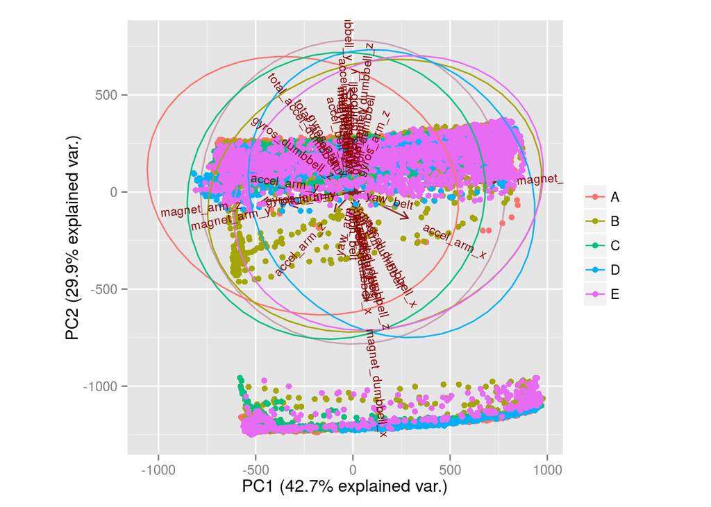

```r
library(ggbiplot)
training.pca <- prcomp(training[1:39])
g <- ggbiplot(training.pca, obs.scale = 1, var.scale = 1, groups = training$classe, ellipse = TRUE, circle = TRUE)
g <- g + scale_color_discrete(name = '')
print(g)
```

## Model Fitting

Use a random forest model to fit the data.

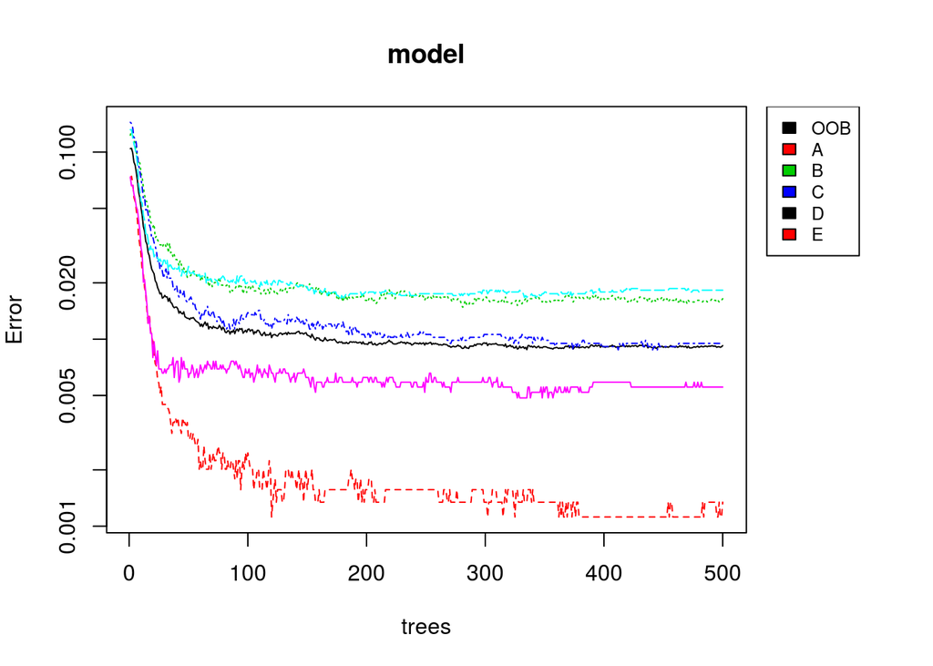

```r
library(randomForest)
model <- randomForest(training[,1:39], training$classe)
layout(matrix(c(1,2),nrow=1),
       width=c(4,1))
par(mar=c(5,4,4,0)) #No margin on the right side
plot(model, log="y")
par(mar=c(5,0,4,2)) #No margin on the left side
plot(c(0,1),type="n", axes=F, xlab="", ylab="")
legend("top", colnames(model$err.rate),col=1:4,cex=0.8,fill=1:4)
```

## Evaluating the Model

Evaluate the out of the sample error using the testing set.

```r
predictions <- predict(model, testing)
confusionMatrix(predictions, testing$classe)
```

```
## Confusion Matrix and Statistics
##
##           Reference
## Prediction    A    B    C    D    E
##          A 1113    8    0    0    0
##          B    2  747    9    0    1
##          C    1    4  674   12    1
##          D    0    0    1  630    1
##          E    0    0    0    1  718
##
## Overall Statistics
##
##                Accuracy : 0.9895
##                  95% CI : (0.9858, 0.9925)
##     No Information Rate : 0.2845
##     P-Value [Acc > NIR] : < 2.2e-16
##
##                   Kappa : 0.9868
##  Mcnemar's Test P-Value : NA
##
## Statistics by Class:
##
##                      Class: A Class: B Class: C Class: D Class: E
## Sensitivity            0.9973   0.9842   0.9854   0.9798   0.9958
## Specificity            0.9971   0.9962   0.9944   0.9994   0.9997
## Pos Pred Value         0.9929   0.9842   0.9740   0.9968   0.9986
## Neg Pred Value         0.9989   0.9962   0.9969   0.9960   0.9991
## Prevalence             0.2845   0.1935   0.1744   0.1639   0.1838
## Detection Rate         0.2837   0.1904   0.1718   0.1606   0.1830
## Detection Prevalence   0.2858   0.1935   0.1764   0.1611   0.1833
## Balanced Accuracy      0.9972   0.9902   0.9899   0.9896   0.9978
```

## Predicting the Outcome

Predict the outcome applying the model to the new data set.

```r
testingData <- read.csv("data/pml-testing.csv")
predictions <- predict(model, testingData[,predictors])
predictions
```

```
##  1  2  3  4  5  6  7  8  9 10 11 12 13 14 15 16 17 18 19 20
##  B  A  B  A  A  E  D  B  A  A  B  C  B  A  E  E  A  B  B  B
## Levels: A B C D E
```